# Predict Bike Sharing Demand with AutoGluon Template

## Project: Predict Bike Sharing Demand with AutoGluon

This notebook is a template with each step that you need to complete for the project.

Please fill in your code where there are explicit `?` markers in the notebook. You are welcome to add more cells and code as you see fit.

Once you have completed all the code implementations, please export your notebook as a HTML file so the reviews can view your code. Make sure you have all outputs correctly outputted.

`File-> Export Notebook As... -> Export Notebook as HTML`

There is a writeup to complete as well after all code implememtation is done. Please answer all questions and attach the necessary tables and charts. You can complete the writeup in either markdown or PDF.

Completing the code template and writeup template will cover all of the rubric points for this project.

The rubric contains "Stand Out Suggestions" for enhancing the project beyond the minimum requirements. The stand out suggestions are optional. If you decide to pursue the "stand out suggestions", you can include the code in this notebook and also discuss the results in the writeup file.

## Step 1: Create an account with Kaggle

### Create Kaggle Account and download API key

Below is example of steps to get the API username and key. Each student will have their own username and key.

1. Open account settings.

2. Scroll down to API and click Create New API Token.

3. Open up `kaggle.json` and use the username and key.


## Step 2: Download the Kaggle dataset using the kaggle python library

### Open up Sagemaker Studio and use starter template

1. Notebook should be using a `ml.t3.medium` instance (2 vCPU + 4 GiB)
2. Notebook should be using kernal: `Python 3 (MXNet 1.8 Python 3.7 CPU Optimized)`

### Install packages

```python
!pip install -U pip
!pip install -U setuptools wheel
!pip install -U "mxnet<2.0.0" bokeh==2.0.1
!pip install autogluon --no-cache-dir
# Without --no-cache-dir, smaller aws instances may have trouble installing
```

### Setup Kaggle API Key

```python
# I've imported my kaggle.json file and move it in the right directory
import os

# Define the correct path for SageMaker Studio user
kaggle_dir = os.path.expanduser("~/.kaggle")
kaggle_path = os.path.join(kaggle_dir, "kaggle.json")

# Create the .kaggle directory
os.makedirs(kaggle_dir, exist_ok=True)

# If you have your kaggle.json ready to upload, upload it via the Jupyter file upload button
# and move it to the right location:
import shutil
shutil.move("kaggle.json", kaggle_path)  # This assumes you uploaded 'kaggle.json' to the notebook directory

# Set proper file permissions
os.chmod(kaggle_path, 0o600)
```

```python
#check if the file has been moved in the right directory
kaggle_path = os.path.expanduser("~/.kaggle/kaggle.json")

print("Exists:", os.path.exists(kaggle_path))
print("Permissions:", oct(os.stat(kaggle_path).st_mode)[-3:])
```

```
Exists: True
Permissions: 600
```

### Download and explore dataset

### Go to the [bike sharing demand competition](https://www.kaggle.com/c/bike-sharing-demand) and agree to the terms

```python
# Download the dataset, it will be in a .zip file so you'll need to unzip it as well.
!pip install -q kaggle
!kaggle competitions download -c bike-sharing-demand
# If you already downloaded it you can use the -o command to overwrite the file
!unzip -o bike-sharing-demand.zip
```

```
Downloading bike-sharing-demand.zip to /home/sagemaker-user/nd009t-c1-intro-to-ml-project-starter
Archive:  bike-sharing-demand.zip
  inflating: sampleSubmission.csv
  inflating: test.csv
  inflating: train.csv
```

```python
import pandas as pd
from autogluon.tabular import TabularPredictor
```

```python
# Create the train dataset in pandas by reading the csv
# Set the parsing of the datetime column so you can use some of the `dt` features in pandas later
train = pd.read_csv("./train.csv", parse_dates=["datetime"])
train.head()
```

|  | datetime | season | holiday | workingday | weather | temp | atemp | humidity | windspeed | casual | registered | count |
| --- | --- | --- | --- | --- | --- | --- | --- | --- | --- | --- | --- | --- |
| 0 | 2011-01-01 00:00:00 | 1 | 0 | 0 | 1 | 9.84 | 14.395 | 81 | 0.0 | 3 | 13 | 16 |
| 1 | 2011-01-01 01:00:00 | 1 | 0 | 0 | 1 | 9.02 | 13.635 | 80 | 0.0 | 8 | 32 | 40 |
| 2 | 2011-01-01 02:00:00 | 1 | 0 | 0 | 1 | 9.02 | 13.635 | 80 | 0.0 | 5 | 27 | 32 |
| 3 | 2011-01-01 03:00:00 | 1 | 0 | 0 | 1 | 9.84 | 14.395 | 75 | 0.0 | 3 | 10 | 13 |
| 4 | 2011-01-01 04:00:00 | 1 | 0 | 0 | 1 | 9.84 | 14.395 | 75 | 0.0 | 0 | 1 | 1 |

```python
# Simple output of the train dataset to view some of the min/max/varition of the dataset features.
train.describe()
```

|  | datetime | season | holiday | workingday | weather | temp | atemp | humidity | windspeed | casual | registered | count |
| --- | --- | --- | --- | --- | --- | --- | --- | --- | --- | --- | --- | --- |
| count | 10886 | 10886.000000 | 10886.000000 | 10886.000000 | 10886.000000 | 10886.00000 | 10886.000000 | 10886.000000 | 10886.000000 | 10886.000000 | 10886.000000 | 10886.000000 |
| mean | 2011-12-27 05:56:22.399411968 | 2.506614 | 0.028569 | 0.680875 | 1.418427 | 20.23086 | 23.655084 | 61.886460 | 12.799395 | 36.021955 | 155.552177 | 191.574132 |
| min | 2011-01-01 00:00:00 | 1.000000 | 0.000000 | 0.000000 | 1.000000 | 0.82000 | 0.760000 | 0.000000 | 0.000000 | 0.000000 | 0.000000 | 1.000000 |
| 25% | 2011-07-02 07:15:00 | 2.000000 | 0.000000 | 0.000000 | 1.000000 | 13.94000 | 16.665000 | 47.000000 | 7.001500 | 4.000000 | 36.000000 | 42.000000 |
| 50% | 2012-01-01 20:30:00 | 3.000000 | 0.000000 | 1.000000 | 1.000000 | 20.50000 | 24.240000 | 62.000000 | 12.998000 | 17.000000 | 118.000000 | 145.000000 |
| 75% | 2012-07-01 12:45:00 | 4.000000 | 0.000000 | 1.000000 | 2.000000 | 26.24000 | 31.060000 | 77.000000 | 16.997900 | 49.000000 | 222.000000 | 284.000000 |
| max | 2012-12-19 23:00:00 | 4.000000 | 1.000000 | 1.000000 | 4.000000 | 41.00000 | 45.455000 | 100.000000 | 56.996900 | 367.000000 | 886.000000 | 977.000000 |
| std | NaN | 1.116174 | 0.166599 | 0.466159 | 0.633839 | 7.79159 | 8.474601 | 19.245033 | 8.164537 | 49.960477 | 151.039033 | 181.144454 |

```python
# Create the test pandas dataframe in pandas by reading the csv, remember to parse the datetime!
test = pd.read_csv("./test.csv", parse_dates=["datetime"])
test.head()
```

|  | datetime | season | holiday | workingday | weather | temp | atemp | humidity | windspeed |
| --- | --- | --- | --- | --- | --- | --- | --- | --- | --- |
| 0 | 2011-01-20 00:00:00 | 1 | 0 | 1 | 1 | 10.66 | 11.365 | 56 | 26.0027 |
| 1 | 2011-01-20 01:00:00 | 1 | 0 | 1 | 1 | 10.66 | 13.635 | 56 | 0.0000 |
| 2 | 2011-01-20 02:00:00 | 1 | 0 | 1 | 1 | 10.66 | 13.635 | 56 | 0.0000 |
| 3 | 2011-01-20 03:00:00 | 1 | 0 | 1 | 1 | 10.66 | 12.880 | 56 | 11.0014 |
| 4 | 2011-01-20 04:00:00 | 1 | 0 | 1 | 1 | 10.66 | 12.880 | 56 | 11.0014 |

```python
# Same thing as train and test dataset
submission = pd.read_csv("./sampleSubmission.csv", parse_dates=["datetime"])
submission.head()
```

|  | datetime | count |
| --- | --- | --- |
| 0 | 2011-01-20 00:00:00 | 0 |
| 1 | 2011-01-20 01:00:00 | 0 |
| 2 | 2011-01-20 02:00:00 | 0 |
| 3 | 2011-01-20 03:00:00 | 0 |
| 4 | 2011-01-20 04:00:00 | 0 |

## Step 3: Train a model using AutoGluon’s Tabular Prediction

Requirements:

- We are predicting `count`, so it is the label we are setting.
- Ignore `casual` and `registered` columns as they are also not present in the test dataset.
- Use the `root_mean_squared_error` as the metric to use for evaluation.
- Set a time limit of 10 minutes (600 seconds).
- Use the preset `best_quality` to focus on creating the best model.

```python
train_data = train.drop(columns=["casual", "registered"])
predictor = TabularPredictor(
    label="count",
    eval_metric="root_mean_squared_error"
).fit(
    train_data,
    time_limit=600,
    presets="best_quality"
)
```

[output not shown]

[output cut: 36 more lines]

```
(_dystack pid=1052) 	'XT': [{'criterion': 'gini', 'ag_args': {'name_suffix': 'Gini', 'problem_types': ['binary', 'multiclass']}}, {'criterion': 'entropy', 'ag_args': {'name_suffix': 'Entr', 'problem_types': ['binary', 'multiclass']}}, {'criterion': 'squared_error', 'ag_args': {'name_suffix': 'MSE', …
(_dystack pid=1052) 	'KNN': [{'weights': 'uniform', 'ag_args': {'name_suffix': 'Unif'}}, {'weights': 'distance', 'ag_args': {'name_suffix': 'Dist'}}],
(_dystack pid=1052) }
(_dystack pid=1052) AutoGluon will fit 2 stack levels (L1 to L2) ...
(_dystack pid=1052) Fitting 108 L1 models, fit_strategy="sequential" ...
(_dystack pid=1052) Fitting model: KNeighborsUnif_BAG_L1 ... Training model for up to 96.23s of the 144.37s of remaining time.
(_dystack pid=1052) 	-107.445	 = Validation score   (-root_mean_squared_error)
(_dystack pid=1052) 	0.02s	 = Training   runtime
(_dystack pid=1052) 	0.05s	 = Validation runtime
(_dystack pid=1052) Fitting model: KNeighborsDist_BAG_L1 ... Training model for up to 92.69s of the 140.83s of remaining time.
(_dystack pid=1052) 	-89.9469	 = Validation score   (-root_mean_squared_error)
(_dystack pid=1052) 	0.02s	 = Training   runtime
(_dystack pid=1052) 	0.05s	 = Validation runtime
(_dystack pid=1052) Fitting model: LightGBMXT_BAG_L1 ... Training model for up to 92.61s of the 140.76s of remaining time.
(_dystack pid=1052) 	Fitting 8 child models (S1F1 - S1F8) | Fitting with ParallelLocalFoldFittingStrategy (2 workers, per: cpus=1, gpus=0, memory=0.95%)
```

```
(_ray_fit pid=1195) [1000]	valid_set's rmse: 129.692
(_ray_fit pid=1300) [1000]	valid_set's rmse: 132.725 [repeated 5x across cluster] (Ray deduplicates logs by default. Set RAY_DEDUP_LOGS=0 to disable log deduplication, or see https://docs.ray.io/en/master/ray-observability/user-guides/configure-logging.html#log-deduplication for more options.)
(_ray_fit pid=1333) [2000]	valid_set's rmse: 126.702 [repeated 2x across cluster]
(_ray_fit pid=1368) [3000]	valid_set's rmse: 133.639 [repeated 7x across cluster]
(_ray_fit pid=1368) [7000]	valid_set's rmse: 132.416 [repeated 7x across cluster]
(_ray_fit pid=1407) [1000]	valid_set's rmse: 137.712 [repeated 3x across cluster]
(_ray_fit pid=1407) [5000]	valid_set's rmse: 135.358 [repeated 5x across cluster]
```

```
(_dystack pid=1052) 	-131.9758	 = Validation score   (-root_mean_squared_error)
(_dystack pid=1052) 	56.12s	 = Training   runtime
(_dystack pid=1052) 	11.32s	 = Validation runtime
(_dystack pid=1052) Fitting model: LightGBM_BAG_L1 ... Training model for up to 30.14s of the 78.28s of remaining time.
(_dystack pid=1052) 	Fitting 8 child models (S1F1 - S1F8) | Fitting with ParallelLocalFoldFittingStrategy (2 workers, per: cpus=1, gpus=0, memory=1.00%)
```

```
(_ray_fit pid=1480) [1000]	valid_set's rmse: 129.285 [repeated 8x across cluster]
```

[output not shown]

```
(_ray_fit pid=1553) [1000]	valid_set's rmse: 135.098 [repeated 2x across cluster]
(_ray_fit pid=1618) [1000]	valid_set's rmse: 124.896
(_ray_fit pid=1649) [1000]	valid_set's rmse: 134.058
```

[output not shown]

```
(_ray_fit pid=1685) [1000]	valid_set's rmse: 134.479
(_ray_fit pid=1718) [1000]	valid_set's rmse: 136.511
```

```
(_dystack pid=1052) 	-131.8496	 = Validation score   (-root_mean_squared_error)
(_dystack pid=1052) 	26.1s	 = Training   runtime
(_dystack pid=1052) 	1.18s	 = Validation runtime
(_dystack pid=1052) Fitting model: RandomForestMSE_BAG_L1 ... Training model for up to 0.44s of the 48.58s of remaining time.
(_dystack pid=1052) /opt/conda/lib/python3.12/site-packages/sklearn/base.py:474: FutureWarning: `BaseEstimator._validate_data` is deprecated in 1.6 and will be removed in 1.7. Use `sklearn.utils.validation.validate_data` instead. This function becomes public and is part of the scikit-learn developer…
(_dystack pid=1052)   warnings.warn(
(_dystack pid=1052) 	-119.5485	 = Validation score   (-root_mean_squared_error)
(_dystack pid=1052) 	13.15s	 = Training   runtime
(_dystack pid=1052) 	0.66s	 = Validation runtime
(_dystack pid=1052) Fitting model: WeightedEnsemble_L2 ... Training model for up to 144.39s of the 34.25s of remaining time.
(_dystack pid=1052) 	Ensemble Weights: {'KNeighborsDist_BAG_L1': 1.0}
(_dystack pid=1052) 	-89.9469	 = Validation score   (-root_mean_squared_error)
(_dystack pid=1052) 	0.02s	 = Training   runtime
(_dystack pid=1052) 	0.0s	 = Validation runtime
(_dystack pid=1052) Fitting 106 L2 models, fit_strategy="sequential" ...
(_dystack pid=1052) Fitting model: LightGBMXT_BAG_L2 ... Training model for up to 34.23s of the 34.21s of remaining time.
(_dystack pid=1052) 	Fitting 8 child models (S1F1 - S1F8) | Fitting with ParallelLocalFoldFittingStrategy (2 workers, per: cpus=1, gpus=0, memory=0.91%)
```

```
(_ray_fit pid=1765) [1000]	valid_set's rmse: 69.5159
(_ray_fit pid=1766) [1000]	valid_set's rmse: 71.3133
(_ray_fit pid=1843) [1000]	valid_set's rmse: 78.3544
(_ray_fit pid=1844) [1000]	valid_set's rmse: 73.3059
(_ray_fit pid=1844) [2000]	valid_set's rmse: 73.2329
(_ray_fit pid=1908) [1000]	valid_set's rmse: 75.7703
(_ray_fit pid=1943) [1000]	valid_set's rmse: 76.8744
(_ray_fit pid=1985) [1000]	valid_set's rmse: 71.8442
(_ray_fit pid=2016) [1000]	valid_set's rmse: 74.306
```

[output not shown]

```
(_ray_fit pid=2016) [2000]	valid_set's rmse: 73.5731
```

[output not shown]

[output cut: 94 more lines]

```
	Fitting 8 child models (S1F1 - S1F8) | Fitting with ParallelLocalFoldFittingStrategy (2 workers, per: cpus=1, gpus=0, memory=1.35%)
	-55.0365	 = Validation score   (-root_mean_squared_error)
	24.73s	 = Training   runtime
	0.33s	 = Validation runtime
Fitting model: RandomForestMSE_BAG_L2 ... Training model for up to 30.82s of the 30.77s of remaining time.
	-53.3574	 = Validation score   (-root_mean_squared_error)
	40.92s	 = Training   runtime
	0.8s	 = Validation runtime
Fitting model: WeightedEnsemble_L3 ... Training model for up to 360.00s of the -11.66s of remaining time.
	Ensemble Weights: {'RandomForestMSE_BAG_L2': 0.72, 'LightGBM_BAG_L2': 0.24, 'LightGBMXT_BAG_L2': 0.04}
	-53.0458	 = Validation score   (-root_mean_squared_error)
	0.03s	 = Training   runtime
	0.0s	 = Validation runtime
AutoGluon training complete, total runtime = 443.6s ... Best model: WeightedEnsemble_L3 | Estimated inference throughput: 78.0 rows/s (1361 batch size)
TabularPredictor saved. To load, use: predictor = TabularPredictor.load("/home/sagemaker-user/nd009t-c1-intro-to-ml-project-starter/AutogluonModels/ag-20250603_151551")
```

### Review AutoGluon's training run with ranking of models that did the best.

```python
predictor.fit_summary()
```

```
*** Summary of fit() ***
Estimated performance of each model:
                     model   score_val              eval_metric  pred_time_val    fit_time  pred_time_val_marginal  fit_time_marginal  stack_level  can_infer  fit_order
0      WeightedEnsemble_L3  -53.045816  root_mean_squared_error      19.516592  408.042800                0.000632           0.033930            3       True         13
1   RandomForestMSE_BAG_L2  -53.357430  root_mean_squared_error      15.528193  332.436191                0.803079          40.921613            2       True         12
2          LightGBM_BAG_L2  -55.036480  root_mean_squared_error      15.053632  316.243762                0.328517          24.729183            2       True         11
3        LightGBMXT_BAG_L2  -60.512491  root_mean_squared_error      18.384364  342.358074                3.659249          50.843496            2       True         10
4    KNeighborsDist_BAG_L1  -84.125061  root_mean_squared_error       0.073227    0.061373                0.073227           0.061373            1       True          2
5      WeightedEnsemble_L2  -84.125061  root_mean_squared_error       0.073853    0.085215                0.000626           0.023841            2       True          9
6    KNeighborsUnif_BAG_L1 -101.546199  root_mean_squared_error       0.063735    0.039679                0.063735           0.039679            1       True          1
7   RandomForestMSE_BAG_L1 -116.548359  root_mean_squared_error       0.788045   14.865978                0.788045          14.865978            1       True          5
8     ExtraTreesMSE_BAG_L1 -124.600676  root_mean_squared_error       0.623912    7.748155                0.623912           7.748155            1       True          7
9          CatBoost_BAG_L1 -130.684311  root_mean_squared_error       0.106230  145.450508                0.106230         145.450508            1       True          6
10         LightGBM_BAG_L1 -131.054162  root_mean_squared_error       1.586825   28.745170                1.586825          28.745170            1       True          4
11       LightGBMXT_BAG_L1 -131.460909  root_mean_squared_error      11.142941   53.460738               11.142941          53.460738            1       True          3
12  NeuralNetFastAI_BAG_L1 -142.703822  root_mean_squared_error       0.340198   41.142976                0.340198          41.142976            1       True          8
Number of models trained: 13
Types of models trained:
{'StackerEnsembleModel_NNFastAiTabular', 'StackerEnsembleModel_KNN', 'StackerEnsembleModel_XT', 'WeightedEnsembleModel', 'StackerEnsembleModel_CatBoost', 'StackerEnsembleModel_RF', 'StackerEnsembleModel_LGB'}
Bagging used: True  (with 8 folds)
Multi-layer stack-ensembling used: True  (with 3 levels)
Feature Metadata (Processed):
(raw dtype, special dtypes):
('float', [])                : 3 | ['temp', 'atemp', 'windspeed']
('int', [])                  : 3 | ['season', 'weather', 'humidity']
('int', ['bool'])            : 2 | ['holiday', 'workingday']
('int', ['datetime_as_int']) : 5 | ['datetime', 'datetime.year', 'datetime.month', 'datetime.day', 'datetime.dayofweek']
Plot summary of models saved to file: /home/sagemaker-user/nd009t-c1-intro-to-ml-project-starter/AutogluonModels/ag-20250603_151551/SummaryOfModels.html
*** End of fit() summary ***
```

[output not shown]

[output cut: 166 more lines]

```

     stack_level  can_infer  fit_order
 0             3       True         13
 1             2       True         12
 2             2       True         11
 3             2       True         10
 4             1       True          2
 5             2       True          9
 6             1       True          1
 7             1       True          5
 8             1       True          7
 9             1       True          6
 10            1       True          4
 11            1       True          3
 12            1       True          8  }
```

```python
# Get the best model name
best_model = predictor.model_best
print("Best model for initial training:", best_model)

# Get the leaderboard
leaderboard = predictor.leaderboard()

# Get the RMSE of the best model
best_model_rmse = leaderboard[leaderboard['model'] == best_model]['score_val'].iloc[0]
print(f"Best model initial training Score: {best_model_rmse:.4f}")
```

```
Best model for initial training: WeightedEnsemble_L3
Best model initial training Score: -53.0458
```

### Create predictions from test dataset

```python
import warnings
warnings.filterwarnings('ignore', category=UserWarning, message='load_learner` uses Python')
predictions = predictor.predict(test)
predictions.head()
```

```
0    22.961201
1    41.035439
2    44.565948
3    48.091721
4    51.561405
Name: count, dtype: float32
```

#### NOTE: Kaggle will reject the submission if we don't set everything to be > 0.

```python
# Describe the `predictions` series to see if there are any negative values
predictions.describe()
```

```
count    6493.000000
mean      100.645134
std        89.757362
min         2.917793
25%        20.631424
50%        64.092766
75%       166.436340
max       367.022156
Name: count, dtype: float64
```

```python
# How many negative values do we have?
(predictions < 0).sum()
```

```
0
```

```python
# Set them to zero
predictions[predictions < 0] = 0
```

### Set predictions to submission dataframe, save, and submit

```python
submission["count"] = predictions
submission.to_csv("initial_submission.csv", index=False)
```

```python
!kaggle competitions submit -c bike-sharing-demand -f initial_submission.csv -m "first raw submission"
```

```
Successfully submitted to Bike Sharing Demand
```

#### View submission via the command line or in the web browser under the competition's page - `My Submissions`

```python
!kaggle competitions submissions -c bike-sharing-demand | tail -n +1 | head -n 6
```

```
fileName                     date                        description                             status                     publicScore  privateScore
---------------------------  --------------------------  --------------------------------------  -------------------------  -----------  ------------
initial_submission.csv       2025-06-03 15:32:37.677000  first raw submission                    SubmissionStatus.COMPLETE  1.79608      1.79608
submission_new_hpo.csv       2025-06-03 09:06:25.140000  new features with hyperparameters prev  SubmissionStatus.COMPLETE  0.60587      0.60587
submission_new_hpo.csv       2025-06-03 08:33:57.587000  new features with hyperparameters prev  SubmissionStatus.COMPLETE  0.57841      0.57841
submission_new_features.csv  2025-06-03 07:57:25.263000  new features prev                       SubmissionStatus.COMPLETE  0.53766      0.53766
```

#### Initial score of `publicScore = 1.79608`

## Step 4: Exploratory Data Analysis and Creating an additional feature

- Any additional feature will do, but a great suggestion would be to separate out the datetime into hour, day, or month parts.

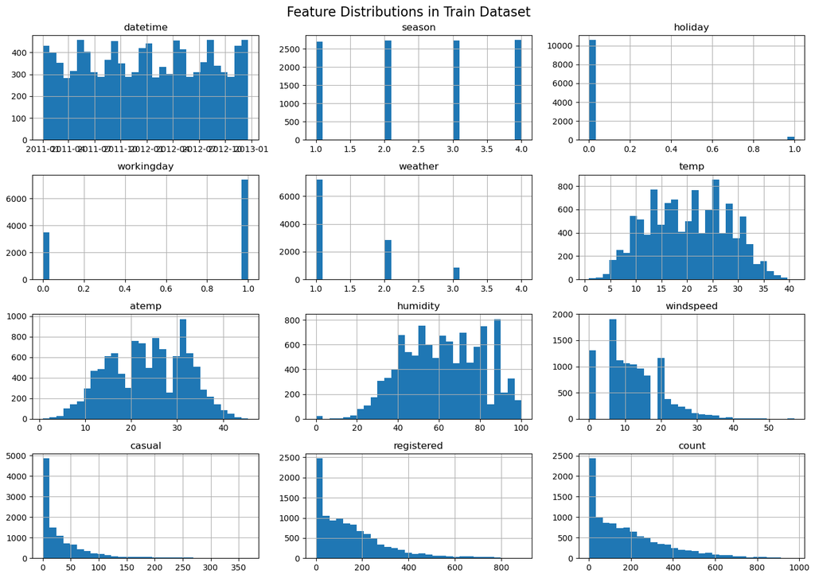

```python
# Create a histogram of all features to show the distribution of each one relative to the data. This is part of the exploritory data analysis
import matplotlib.pyplot as plt

# Plot histogram of all numerical features
train.hist(figsize=(14, 10), bins=30)
plt.suptitle("Feature Distributions in Train Dataset", fontsize=16)
plt.tight_layout()
plt.subplots_adjust(top=0.93)
plt.show()
```

```python
# create a new feature
train["hour"] = train["datetime"].dt.hour
train["day"] = train["datetime"].dt.dayofweek  # 0 = Monday, 6 = Sunday
train["month"] = train["datetime"].dt.month

# Apply the same transformations to the test set
test["hour"] = test["datetime"].dt.hour
test["day"] = test["datetime"].dt.dayofweek
test["month"] = test["datetime"].dt.month
```

## Make category types for these so models know they are not just numbers

```python
train["season"] = train["season"].astype("category")
train["weather"] = train["weather"].astype("category")

test["season"] = test["season"].astype("category")
test["weather"] = test["weather"].astype("category")
```

```python
# View are new feature
train.head()
```

|  | datetime | season | holiday | workingday | weather | temp | atemp | humidity | windspeed | casual | registered | count | hour | day | month |
| --- | --- | --- | --- | --- | --- | --- | --- | --- | --- | --- | --- | --- | --- | --- | --- |
| 0 | 2011-01-01 00:00:00 | 1 | 0 | 0 | 1 | 9.84 | 14.395 | 81 | 0.0 | 3 | 13 | 16 | 0 | 5 | 1 |
| 1 | 2011-01-01 01:00:00 | 1 | 0 | 0 | 1 | 9.02 | 13.635 | 80 | 0.0 | 8 | 32 | 40 | 1 | 5 | 1 |
| 2 | 2011-01-01 02:00:00 | 1 | 0 | 0 | 1 | 9.02 | 13.635 | 80 | 0.0 | 5 | 27 | 32 | 2 | 5 | 1 |
| 3 | 2011-01-01 03:00:00 | 1 | 0 | 0 | 1 | 9.84 | 14.395 | 75 | 0.0 | 3 | 10 | 13 | 3 | 5 | 1 |
| 4 | 2011-01-01 04:00:00 | 1 | 0 | 0 | 1 | 9.84 | 14.395 | 75 | 0.0 | 0 | 1 | 1 | 4 | 5 | 1 |

```
array([[<Axes: title={'center': 'datetime'}>,
        <Axes: title={'center': 'season'}>,
        <Axes: title={'center': 'holiday'}>,
        <Axes: title={'center': 'workingday'}>],
       [<Axes: title={'center': 'weather'}>,
        <Axes: title={'center': 'temp'}>,
        <Axes: title={'center': 'atemp'}>,
        <Axes: title={'center': 'humidity'}>],
       [<Axes: title={'center': 'windspeed'}>,
        <Axes: title={'center': 'casual'}>,
        <Axes: title={'center': 'registered'}>,
        <Axes: title={'center': 'count'}>],
       [<Axes: title={'center': 'hour'}>,
        <Axes: title={'center': 'day'}>,
        <Axes: title={'center': 'month'}>, <Axes: >]], dtype=object)
```

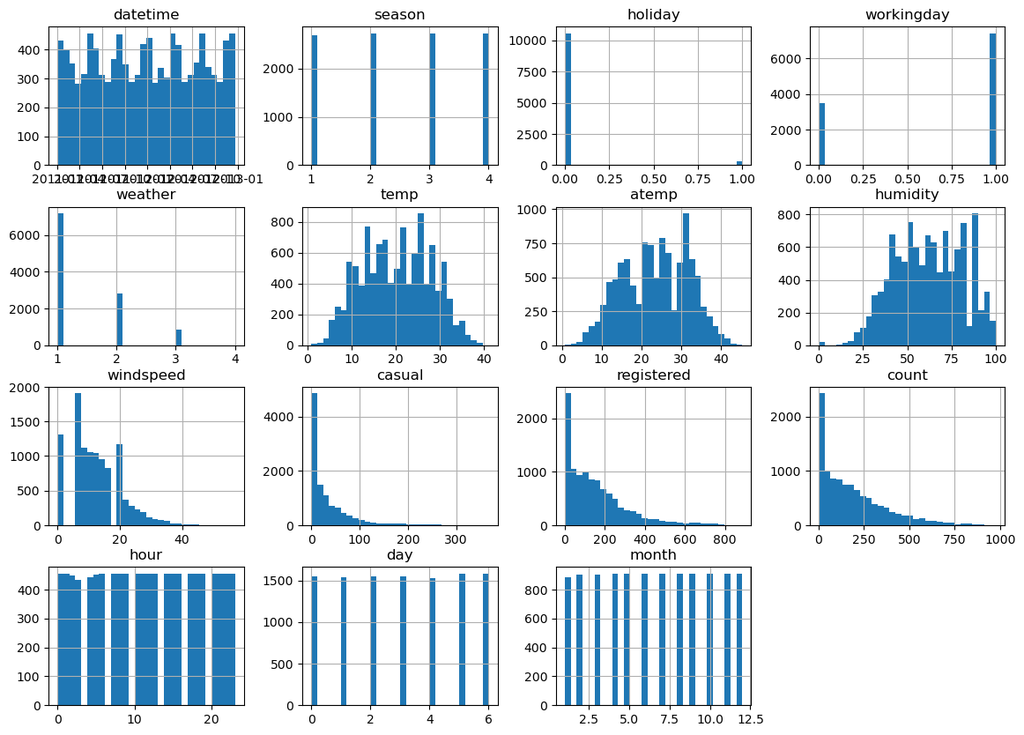

```python
# View histogram of all features again now with the hour feature
train.hist(figsize=(14, 10), bins=30)
```

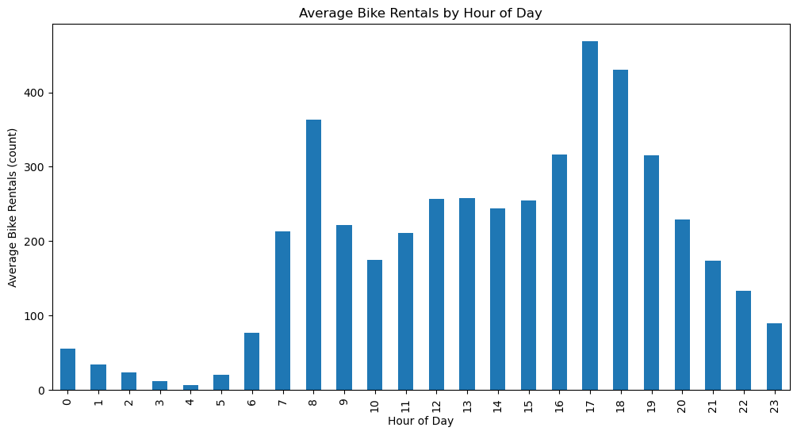

```python
# View histogram of all features group by hour
v_counts = train.groupby("hour")["count"].mean()

# Plot
v_counts.plot(kind='bar', figsize=(12,6))
plt.xlabel('Hour of Day')
plt.ylabel('Average Bike Rentals (count)')
plt.title('Average Bike Rentals by Hour of Day')
plt.show()
```

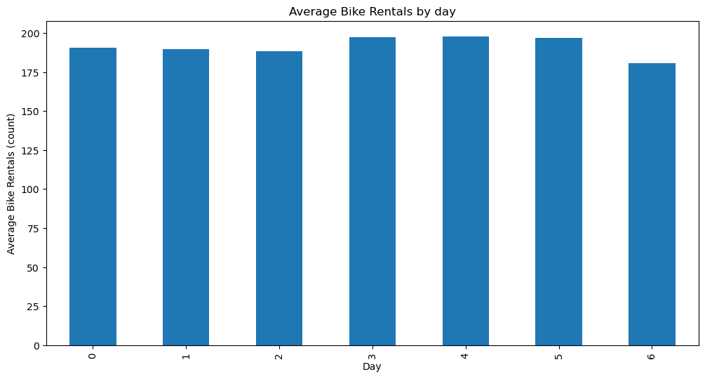

```python
# View histogram of all features group by day
v_counts = train.groupby("day")["count"].mean()

# Plot
v_counts.plot(kind='bar', figsize=(12,6))
plt.xlabel('Day')
plt.ylabel('Average Bike Rentals (count)')
plt.title('Average Bike Rentals by day')
plt.show()
```

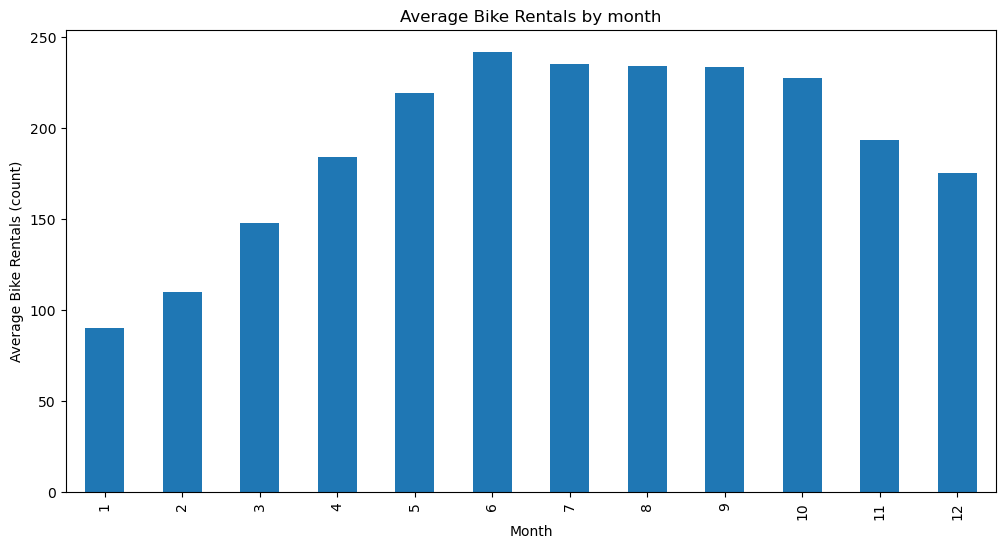

```python
# View histogram of all features group by month
v_counts = train.groupby("month")["count"].mean()

# Plot
v_counts.plot(kind='bar', figsize=(12,6))
plt.xlabel('Month')
plt.ylabel('Average Bike Rentals (count)')
plt.title('Average Bike Rentals by month')
plt.show()
```

## Step 5: Rerun the model with the same settings as before, just with more features

```python
train_data_new = train.drop(columns=["casual", "registered", "datetime"])

predictor_new_features = TabularPredictor(
    label="count",
    eval_metric="root_mean_squared_error"
).fit(
    train_data=train_data_new,
    presets="best_quality",
    time_limit=600
)
```

[output not shown]

[output cut: 122 more lines]

```
	10.94s	 = Training   runtime
	0.78s	 = Validation runtime
Fitting model: NeuralNetFastAI_BAG_L2 ... Training model for up to 7.19s of the 7.15s of remaining time.
	Fitting 8 child models (S1F1 - S1F8) | Fitting with ParallelLocalFoldFittingStrategy (2 workers, per: cpus=1, gpus=0, memory=0.85%)
I0000 00:00:1748966656.244173    1150 chttp2_transport.cc:1182] ipv4:169.255.255.2:39587: Got goaway [2] err=UNAVAILABLE:GOAWAY received; Error code: 2; Debug Text: Cancelling all calls {grpc_status:14, http2_error:2, created_time:"2025-06-03T16:04:16.244167847+00:00"}
	-71.4972	 = Validation score   (-root_mean_squared_error)
	35.71s	 = Training   runtime
	0.38s	 = Validation runtime
Fitting model: WeightedEnsemble_L3 ... Training model for up to 360.00s of the -32.16s of remaining time.
	Ensemble Weights: {'CatBoost_BAG_L2': 0.375, 'ExtraTreesMSE_BAG_L2': 0.292, 'LightGBMXT_BAG_L1': 0.125, 'LightGBM_BAG_L1': 0.083, 'LightGBM_BAG_L2': 0.083, 'CatBoost_BAG_L1': 0.042}
	-54.0629	 = Validation score   (-root_mean_squared_error)
	0.04s	 = Training   runtime
	0.0s	 = Validation runtime
AutoGluon training complete, total runtime = 437.55s ... Best model: WeightedEnsemble_L3 | Estimated inference throughput: 30.8 rows/s (1361 batch size)
TabularPredictor saved. To load, use: predictor = TabularPredictor.load("/home/sagemaker-user/nd009t-c1-intro-to-ml-project-starter/AutogluonModels/ag-20250603_155344")
```

```python
predictor_new_features.fit_summary()
```

```
*** Summary of fit() ***
Estimated performance of each model:
                     model   score_val              eval_metric  pred_time_val    fit_time  pred_time_val_marginal  fit_time_marginal  stack_level  can_infer  fit_order
0      WeightedEnsemble_L3  -54.062894  root_mean_squared_error      46.125884  313.982887                0.000666           0.036862            3       True         15
1          CatBoost_BAG_L2  -54.416200  root_mean_squared_error      45.264453  281.399555                0.051781          32.877039            2       True         12
2     ExtraTreesMSE_BAG_L2  -54.650457  root_mean_squared_error      45.987983  259.460274                0.775311          10.937757            2       True         13
3      WeightedEnsemble_L2  -54.813246  root_mean_squared_error      43.837245  233.857054                0.000918           0.041967            2       True          8
4          LightGBM_BAG_L2  -54.918979  root_mean_squared_error      45.298125  270.131229                0.085454          21.608712            2       True         10
5        LightGBMXT_BAG_L2  -55.452576  root_mean_squared_error      45.489849  271.364639                0.277177          22.842123            2       True          9
6   RandomForestMSE_BAG_L2  -55.586065  root_mean_squared_error      45.563020  266.994100                0.350348          18.471583            2       True         11
7          LightGBM_BAG_L1  -56.170341  root_mean_squared_error       4.772736   41.081496                4.772736          41.081496            1       True          4
8        LightGBMXT_BAG_L1  -56.847751  root_mean_squared_error      38.967843  101.303863               38.967843         101.303863            1       True          3
9          CatBoost_BAG_L1  -57.173250  root_mean_squared_error       0.095748   91.429728                0.095748          91.429728            1       True          6
10  RandomForestMSE_BAG_L1  -64.236861  root_mean_squared_error       0.676984   11.776024                0.676984          11.776024            1       True          5
11    ExtraTreesMSE_BAG_L1  -65.357736  root_mean_squared_error       0.336223    2.874143                0.336223           2.874143            1       True          7
12  NeuralNetFastAI_BAG_L2  -71.497247  root_mean_squared_error      45.589931  284.229634                0.377259          35.707117            2       True         14
13   KNeighborsDist_BAG_L1 -111.967547  root_mean_squared_error       0.227536    0.025800                0.227536           0.025800            1       True          2
14   KNeighborsUnif_BAG_L1 -115.580866  root_mean_squared_error       0.135602    0.031462                0.135602           0.031462            1       True          1
Number of models trained: 15
Types of models trained:
{'StackerEnsembleModel_NNFastAiTabular', 'StackerEnsembleModel_KNN', 'StackerEnsembleModel_XT', 'WeightedEnsembleModel', 'StackerEnsembleModel_CatBoost', 'StackerEnsembleModel_RF', 'StackerEnsembleModel_LGB'}
Bagging used: True  (with 8 folds)
Multi-layer stack-ensembling used: True  (with 3 levels)
Feature Metadata (Processed):
(raw dtype, special dtypes):
('float', [])     : 3 | ['temp', 'atemp', 'windspeed']
('int', [])       : 6 | ['season', 'weather', 'humidity', 'hour', 'day', ...]
('int', ['bool']) : 2 | ['holiday', 'workingday']
Plot summary of models saved to file: /home/sagemaker-user/nd009t-c1-intro-to-ml-project-starter/AutogluonModels/ag-20250603_155344/SummaryOfModels.html
*** End of fit() summary ***
```

[output not shown]

[output cut: 199 more lines]

```
 0             3       True         15
 1             2       True         12
 2             2       True         13
 3             2       True          8
 4             2       True         10
 5             2       True          9
 6             2       True         11
 7             1       True          4
 8             1       True          3
 9             1       True          6
 10            1       True          5
 11            1       True          7
 12            2       True         14
 13            1       True          2
 14            1       True          1  }
```

```python
# Get the best model name
best_model = predictor_new_features.model_best
print("Best model after feature engineering training:", best_model)

# Get the leaderboard
leaderboard = predictor_new_features.leaderboard()

# Get the RMSE of the best model
best_model_rmse = leaderboard[leaderboard['model'] == best_model]['score_val'].iloc[0]
print(f"Best model after feature engineering training Score: {best_model_rmse:.4f}")
```

```
Best model after feature engineering training: WeightedEnsemble_L3
Best model after feature engineering training Score: -54.0629
```

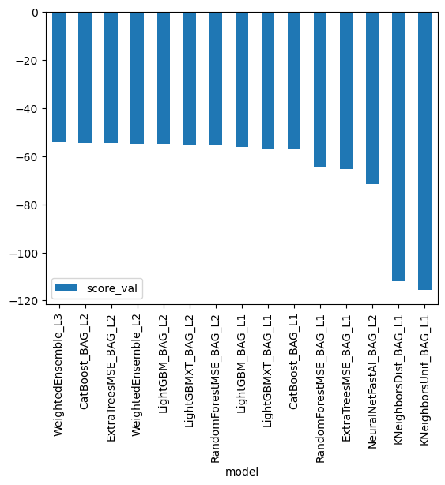

```python
#plot the leaderboard
predictor_new_features.leaderboard(silent=True).plot(kind="bar", x="model", y="score_val");
```

```python
# Remember to set all negative values to zero

test_features = test.drop(columns=["datetime"])

# Predict
predictions = predictor_new_features.predict(test_features)
```

```python
# Same submitting predictions
predictions[predictions < 0] = 0
submission_new_features = pd.read_csv("./sampleSubmission.csv", parse_dates=["datetime"])
submission_new_features["count"] = predictions
submission_new_features.to_csv("feature_submission_new_features.csv", index=False)
```

```python
!kaggle competitions submit -c bike-sharing-demand -f feature_submission_new_features.csv -m "new features"
```

```
Successfully submitted to Bike Sharing Demand
```

```python
!kaggle competitions submissions -c bike-sharing-demand | tail -n +1 | head -n 6
```

```
fileName                             date                        description                             status                     publicScore  privateScore
-----------------------------------  --------------------------  --------------------------------------  -------------------------  -----------  ------------
feature_submission_new_features.csv  2025-06-03 16:16:48.333000  new features                            SubmissionStatus.COMPLETE  0.53143      0.53143
feature_submission_new_features.csv  2025-06-03 16:11:00.983000  new features                            SubmissionStatus.ERROR
initial_submission.csv               2025-06-03 15:32:37.677000  first raw submission                    SubmissionStatus.COMPLETE  1.79608      1.79608
submission_new_hpo.csv               2025-06-03 09:06:25.140000  new features with hyperparameters prev  SubmissionStatus.COMPLETE  0.60587      0.60587
```

#### New Score of `publicScore = 0.53143`

## Step 6: Hyper parameter optimization

- There are many options for hyper parameter optimization.
- Options are to change the AutoGluon higher level parameters or the individual model hyperparameters.
- The hyperparameters of the models themselves that are in AutoGluon. Those need the `hyperparameter` and `hyperparameter_tune_kwargs` arguments.

```python
from autogluon.common import space as ag_space


# Define search-spaces for each model type


nn_options = {
    "num_epochs": 30,
    "learning_rate": ag_space.Real(1e-4, 1e-2, log=True, default=5e-4),
    "activation":   ag_space.Categorical("relu", "softrelu", "tanh"),
    "dropout_prob": ag_space.Real(0.0, 0.5, default=0.1),
}

gbm_options = {                    # LightGBM search-space
    "num_boost_round": 100,
    "num_leaves":     ag_space.Int(26, 66, default=36),
}

rf_options = {                     # Random-Forest search-space
    "n_estimators":    ag_space.Int(300, 800, default=500),
    "max_depth":       ag_space.Int(8, 25,   default=15),
    "min_samples_leaf":ag_space.Int(1, 10,   default=2),
    "max_features":    ag_space.Real(0.3, 1.0, default=0.7),
}

hyperparameters = {
    "GBM"      : gbm_options,   # LightGBM
    "NN_TORCH" : nn_options,    # Torch neural net
    "RF"       : rf_options,    # Random-Forest
}

# HPO scheduler / searcher configuration

hpo_kwargs = {
    "num_trials": 5,
    "scheduler" : "local",
    "searcher"  : "auto",   # AutoGluon picks random or bayesopt
}



# Train with hyper-parameter tuning

predictor_new_hpo = TabularPredictor(
    label="count",
    eval_metric="root_mean_squared_error"
).fit(
    train_data=train_data_new,
    time_limit=600,
    hyperparameters=hyperparameters,
    hyperparameter_tune_kwargs=hpo_kwargs,
)
```

[output not shown]

```python
predictor_new_hpo.fit_summary()
```

```
*** Summary of fit() ***
Estimated performance of each model:
                      model   score_val              eval_metric  pred_time_val   fit_time  pred_time_val_marginal  fit_time_marginal  stack_level  can_infer  fit_order
0           RandomForest/T2  -63.711411  root_mean_squared_error       0.686120   5.948737                0.686120           5.948737            1       True          7
1       WeightedEnsemble_L2  -64.648900  root_mean_squared_error       0.705964   6.605900                0.000474           0.013424            2       True         16
2           RandomForest/T1  -64.953390  root_mean_squared_error       0.726516   7.111239                0.726516           7.111239            1       True          6
3               LightGBM/T3  -66.134691  root_mean_squared_error       0.019370   0.643739                0.019370           0.643739            1       True          3
4               LightGBM/T2  -67.500577  root_mean_squared_error       0.015474   0.608411                0.015474           0.608411            1       True          2
5               LightGBM/T1  -68.031125  root_mean_squared_error       0.016026   0.732243                0.016026           0.732243            1       True          1
6           RandomForest/T3  -68.939476  root_mean_squared_error       0.790187   6.988883                0.790187           6.988883            1       True          8
7               LightGBM/T5  -69.575663  root_mean_squared_error       0.016284   0.645389                0.016284           0.645389            1       True          5
8           RandomForest/T5  -69.768415  root_mean_squared_error       1.130874   3.113555                1.130874           3.113555            1       True         10
9           RandomForest/T4  -75.084007  root_mean_squared_error       0.466761   2.840208                0.466761           2.840208            1       True          9
10  NeuralNetTorch/db422bc4  -80.558484  root_mean_squared_error       0.025232  21.719832                0.025232          21.719832            1       True         13
11  NeuralNetTorch/d9c3f52b  -81.674674  root_mean_squared_error       0.023043  22.350199                0.023043          22.350199            1       True         11
12              LightGBM/T4 -127.837103  root_mean_squared_error       0.011095   0.577982                0.011095           0.577982            1       True          4
13  NeuralNetTorch/08fff93c -144.616043  root_mean_squared_error       0.024448  27.374574                0.024448          27.374574            1       True         14
14  NeuralNetTorch/4dcd121a -150.337309  root_mean_squared_error       0.015591  16.303082                0.015591          16.303082            1       True         15
15  NeuralNetTorch/5b48fd89 -150.973266  root_mean_squared_error       0.015624  20.563220                0.015624          20.563220            1       True         12
Number of models trained: 16
Types of models trained:
{'RFModel', 'TabularNeuralNetTorchModel', 'WeightedEnsembleModel', 'LGBModel'}
Bagging used: False
Multi-layer stack-ensembling used: False
Feature Metadata (Processed):
(raw dtype, special dtypes):
('float', [])     : 3 | ['temp', 'atemp', 'windspeed']
('int', [])       : 6 | ['season', 'weather', 'humidity', 'hour', 'day', ...]
('int', ['bool']) : 2 | ['holiday', 'workingday']
Plot summary of models saved to file: /home/sagemaker-user/nd009t-c1-intro-to-ml-project-starter/AutogluonModels/ag-20250603_162927/SummaryOfModels.html
*** End of fit() summary ***
```

[output not shown]

[output cut: 264 more lines]

```
 1             2       True         16
 2             1       True          6
 3             1       True          3
 4             1       True          2
 5             1       True          1
 6             1       True          8
 7             1       True          5
 8             1       True         10
 9             1       True          9
 10            1       True         13
 11            1       True         11
 12            1       True          4
 13            1       True         14
 14            1       True         15
 15            1       True         12  }
```

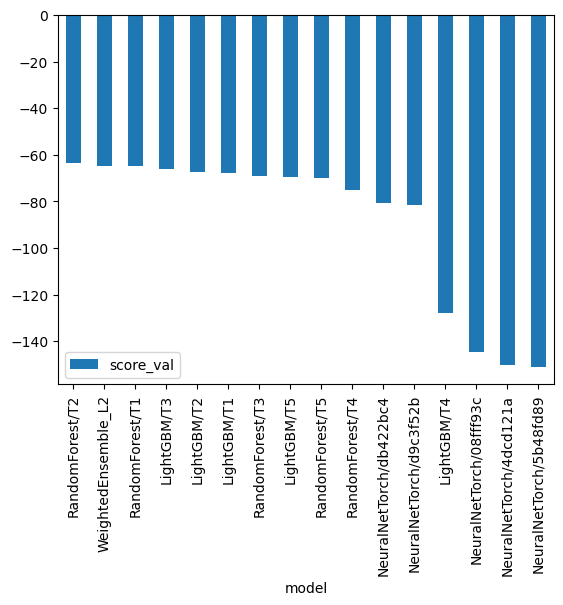

```python
#plot the leaderboard
predictor_new_hpo.leaderboard(silent=True).plot(kind="bar", x="model", y="score_val");
```

```python
# Get the best model name
best_model = predictor_new_hpo.model_best
print("Best model after Hyperparametertraining:", best_model)

# Get the leaderboard
leaderboard = predictor_new_hpo.leaderboard()

# Get the RMSE of the best model
best_model_rmse = leaderboard[leaderboard['model'] == best_model]['score_val'].iloc[0]
print(f"Best model after Hyperparametertraining training Score: {best_model_rmse:.4f}")
```

```
Best model after Hyperparametertraining: WeightedEnsemble_L2
Best model after Hyperparametertraining training Score: -64.6489
```

```python
# Remember to set all negative values to zero
# Predict
predictions = predictor_new_hpo.predict(test_features)
predictions[predictions < 0] = 0
```

```python
# Same submitting predictions
submission_new_hpo = pd.read_csv("./sampleSubmission.csv", parse_dates=["datetime"])
submission_new_hpo["count"] = predictions
submission_new_hpo.to_csv("hyperparameter_submission_new_hpo.csv", index=False)
```

```python
!kaggle competitions submit -c bike-sharing-demand -f hyperparameter_submission_new_hpo.csv -m "new features with hyperparameters"
```

```
Successfully submitted to Bike Sharing Demand
```

```python
!kaggle competitions submissions -c bike-sharing-demand | tail -n +1 | head -n 6
```

```
fileName                               date                        description                             status                     publicScore  privateScore
-------------------------------------  --------------------------  --------------------------------------  -------------------------  -----------  ------------
hyperparameter_submission_new_hpo.csv  2025-06-03 16:36:03.740000  new features with hyperparameters       SubmissionStatus.COMPLETE  0.51194      0.51194
feature_submission_new_features.csv    2025-06-03 16:16:48.333000  new features                            SubmissionStatus.COMPLETE  0.53143      0.53143
feature_submission_new_features.csv    2025-06-03 16:11:00.983000  new features                            SubmissionStatus.ERROR
initial_submission.csv                 2025-06-03 15:32:37.677000  first raw submission                    SubmissionStatus.COMPLETE  1.79608      1.79608
```